# Homework-week-4

Maria C. Codlin

September 27, 2017

# Homework 2

Every Saturday, at the same time, a primatologist goes and sits in the forest in the morning and listens for titi monkey calls, counting the number of calls they hear in a 2 hour window from 5am to 7am. Based on previous knowledge, she believes that the mean number calls she will hear in that time is exactly 15. Let X represent the appropriate Poisson random variable of the number of calls heard in each monitoring session.

What is the probability that she will hear more than 8 calls during any given session? What is the probability that she will hear no calls in a session? What is the probability that she will hear exactly 3 calls in a session? Plot the relevant Poisson mass function over the values in range 0 ≤ x ≤ 30. Simulate 104 results from this distribution (i.e., 2 years of Saturday monitoring sessions). Plot the simulated results using hist() and use xlim() to set the horizontal limits to be from 0 to 30. How does your histogram compare to the shape of the probability mass function you plotted above?

## Answers

### What is the probability that she will hear more than 8 calls during any given session?

```r
round(ppois(8, lambda=15, lower.tail=FALSE), 3)
```

```
## [1] 0.963
```

### What is the probability that she will hear no calls in a session?

```r
round(dpois(0, lambda=15),7)
```

```
## [1] 3e-07
```

### What is the probability that she will hear exactly 3 calls in a session?

```r
round(dpois(3, lambda=15),5) #dpois is exact while ppois is with tail
```

```
## [1] 0.00017
```

### Plot the relevant Poisson mass function over the values in range 0 ≤ x ≤ 30

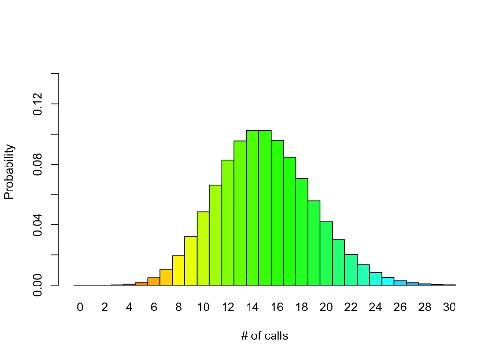

```r
barplot(dpois(x=0:30, lambda=15), ylim=c(0,0.15), space=0, names.arg=0:30, ylab="Probability", xlab="# of calls", col=rainbow(50))
```

### Simulate 104 results from this distribution (i.e., 2 years of Saturday monitoring sessions). Plot the simulated results using hist() and use xlim() to set the horizontal limits to be from 0 to 30. How does your histogram compare to the shape of the probability mass function you plotted above?

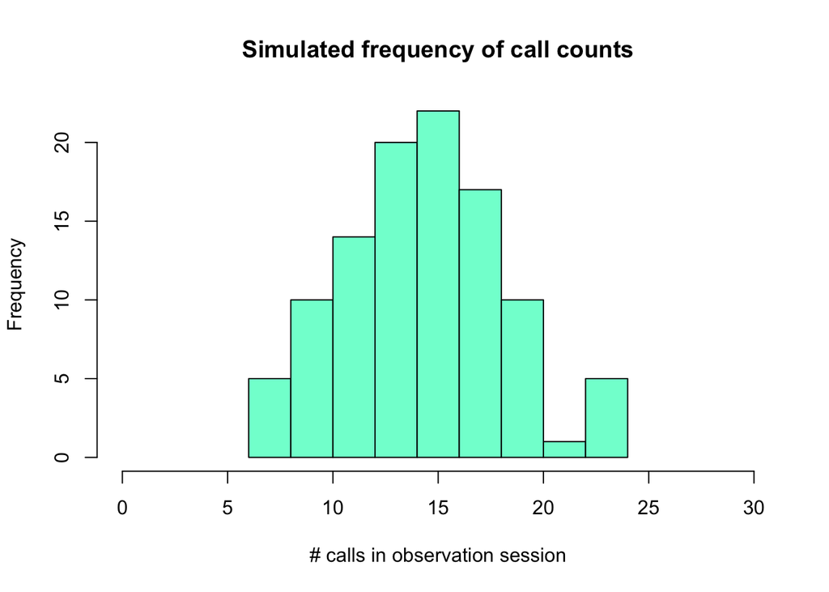

```r
sim<-rpois(n=104, lambda=15)
hist(sim, xlim=c(0,30), ylab="Frequency", xlab="# calls in observation session", main="Simulated frequency of call counts", col="aquamarine")
```

This histogram shows the simulated frequency of observed calls over a two year period. It seems to be a fair approximation of the Poisson Mass distribution above and so it it would likely be an appropriate statistic to apply to this type of data. However, even with 104 simulated cases, the distribution varies quite a lot each time I run the simulation and suggests that it could benefit from a higher sample count.